# Hausarbeit im Modul „Data Science und Machine Learning“ WS22/23 - Teil 1

## Data cleaning

```python
# Python ≥3.5 is required
import sys
assert sys.version_info >= (3, 5)

# Scikit-Learn ≥0.20 is required
import sklearn
assert sklearn.__version__ >= "0.20"

# Common imports
import pandas as pd
import numpy as np
import os

# to make this notebook's output stable across runs
np.random.seed(42)

# To plot pretty figures
%matplotlib inline
import matplotlib as mpl
import matplotlib.pyplot as plt
mpl.rc('axes', labelsize=14)
mpl.rc('xtick', labelsize=12)
mpl.rc('ytick', labelsize=12)

# Where to save the figures
PROJECT_ROOT_DIR = "."
CHAPTER_ID = "classifcation"
IMAGES_PATH = os.path.join(PROJECT_ROOT_DIR, "images", CHAPTER_ID)
os.makedirs(IMAGES_PATH, exist_ok=True)

def save_fig(fig_id, tight_layout=True, fig_extension="png", resolution=300):
    path = os.path.join(IMAGES_PATH, fig_id + "." + fig_extension)
    print("Saving figure", fig_id)
    if tight_layout:
        plt.tight_layout()
    plt.savefig(path, format=fig_extension, dpi=resolution)
```

```python
import pandas as pd

finTechDF = pd.DataFrame(pd.read_csv('https://raw.githubusercontent.com/VAWi-DataScience/Data-Science-and-Machine-Learning/main/Assignment/WiSe22_23/01_FinTech_Churn.csv', sep=";"))
```

```python
finTechDF
```

|  | CCreditScore | CGeography | CGender | CAge | CTenure | CBalance | CNumOfProducts | CHasCrCard | CIsActiveMember | CEstimatedSalary | Churn |
| --- | --- | --- | --- | --- | --- | --- | --- | --- | --- | --- | --- |
| 0 | 619 | France | Female | 42 | 2 | 0.00 | 1 | 1 | 1 | 101348.88 | 1 |
| 1 | 608 | Spain | Female | 41 | 1 | 83807.86 | 1 | 0 | 1 | 112542.58 | 0 |
| 2 | 502 | France | Female | 42 | 8 | 159660.80 | 3 | 1 | 0 | 113931.57 | 1 |
| 3 | 699 | France | Female | 39 | 1 | 0.00 | 2 | 0 | 0 | 93826.63 | 0 |
| 4 | 850 | Spain | Female | 43 | 2 | 125510.82 | 1 | 1 | 1 | 79084.1 | 0 |
| ... | ... | ... | ... | ... | ... | ... | ... | ... | ... | ... | ... |
| 9995 | 771 | France | Male | 39 | 5 | 0.00 | 2 | 1 | 0 | 96270.64 | 0 |
| 9996 | 516 | France | Male | 35 | 10 | 57369.61 | 1 | 1 | 1 | 101699.77 | 0 |
| 9997 | 709 | France | Female | 36 | 7 | 0.00 | 1 | 0 | 1 | 42085.58 | 1 |
| 9998 | 772 | Germany | Male | 42 | 3 | 75075.31 | 2 | 1 | 0 | 92888.52 | 1 |
| 9999 | 792 | France | Female | 28 | 4 | 130142.79 | 1 | 1 | 0 | 38190.78 | 0 |

10000 rows × 11 columns

```python
print(finTechDF.dtypes)
```

```
CCreditScore          int64
CGeography           object
CGender              object
CAge                  int64
CTenure               int64
CBalance            float64
CNumOfProducts        int64
CHasCrCard            int64
CIsActiveMember       int64
CEstimatedSalary     object
Churn                 int64
dtype: object
```

```python
finTechDF['CEstimatedSalary'] = pd.to_numeric(finTechDF['CEstimatedSalary'], errors='coerce')
finTechDF.isna().sum()
```

```
CCreditScore        0
CGeography          0
CGender             0
CAge                0
CTenure             0
CBalance            0
CNumOfProducts      0
CHasCrCard          0
CIsActiveMember     0
CEstimatedSalary    1
Churn               0
dtype: int64
```

```python
finTechDF.dropna()
finTechDF.dtypes
```

```
CCreditScore          int64
CGeography           object
CGender              object
CAge                  int64
CTenure               int64
CBalance            float64
CNumOfProducts        int64
CHasCrCard            int64
CIsActiveMember       int64
CEstimatedSalary    float64
Churn                 int64
dtype: object
```

```python
finTechDF = pd.get_dummies(finTechDF, columns=['CGeography'], dtype='int64', drop_first=True)
finTechDF = pd.get_dummies(finTechDF, columns=['CGender'], dtype='int64', drop_first=True)
finTechDF
```

|  | CCreditScore | CAge | CTenure | CBalance | CNumOfProducts | CHasCrCard | CIsActiveMember | CEstimatedSalary | Churn | CGeography_Germany | CGeography_Spain | CGender_Male |
| --- | --- | --- | --- | --- | --- | --- | --- | --- | --- | --- | --- | --- |
| 0 | 619 | 42 | 2 | 0.00 | 1 | 1 | 1 | 101348.88 | 1 | 0 | 0 | 0 |
| 1 | 608 | 41 | 1 | 83807.86 | 1 | 0 | 1 | 112542.58 | 0 | 0 | 1 | 0 |
| 2 | 502 | 42 | 8 | 159660.80 | 3 | 1 | 0 | 113931.57 | 1 | 0 | 0 | 0 |
| 3 | 699 | 39 | 1 | 0.00 | 2 | 0 | 0 | 93826.63 | 0 | 0 | 0 | 0 |
| 4 | 850 | 43 | 2 | 125510.82 | 1 | 1 | 1 | 79084.10 | 0 | 0 | 1 | 0 |
| ... | ... | ... | ... | ... | ... | ... | ... | ... | ... | ... | ... | ... |
| 9995 | 771 | 39 | 5 | 0.00 | 2 | 1 | 0 | 96270.64 | 0 | 0 | 0 | 1 |
| 9996 | 516 | 35 | 10 | 57369.61 | 1 | 1 | 1 | 101699.77 | 0 | 0 | 0 | 1 |
| 9997 | 709 | 36 | 7 | 0.00 | 1 | 0 | 1 | 42085.58 | 1 | 0 | 0 | 0 |
| 9998 | 772 | 42 | 3 | 75075.31 | 2 | 1 | 0 | 92888.52 | 1 | 1 | 0 | 1 |
| 9999 | 792 | 28 | 4 | 130142.79 | 1 | 1 | 0 | 38190.78 | 0 | 0 | 0 | 0 |

10000 rows × 12 columns

```python
finTechDF.describe()
```

|  | CCreditScore | CAge | CTenure | CBalance | CNumOfProducts | CHasCrCard | CIsActiveMember | CEstimatedSalary | Churn | CGeography_Germany | CGeography_Spain | CGender_Male |
| --- | --- | --- | --- | --- | --- | --- | --- | --- | --- | --- | --- | --- |
| count | 10000.000000 | 10000.000000 | 10000.000000 | 10000.000000 | 10000.000000 | 10000.00000 | 10000.000000 | 9999.000000 | 10000.000000 | 10000.000000 | 10000.000000 | 10000.000000 |
| mean | 650.528800 | 38.921800 | 5.012800 | 76485.889288 | 1.530200 | 0.70550 | 0.515100 | 100100.248748 | 0.203700 | 0.250900 | 0.247700 | 0.545700 |
| std | 96.653299 | 10.487806 | 2.892174 | 62397.405202 | 0.581654 | 0.45584 | 0.499797 | 57504.658260 | 0.402769 | 0.433553 | 0.431698 | 0.497932 |
| min | 350.000000 | 18.000000 | 0.000000 | 0.000000 | 1.000000 | 0.00000 | 0.000000 | 90.070000 | 0.000000 | 0.000000 | 0.000000 | 0.000000 |
| 25% | 584.000000 | 32.000000 | 3.000000 | 0.000000 | 1.000000 | 0.00000 | 0.000000 | 51013.655000 | 0.000000 | 0.000000 | 0.000000 | 0.000000 |
| 50% | 652.000000 | 37.000000 | 5.000000 | 97198.540000 | 1.000000 | 1.00000 | 1.000000 | 100200.400000 | 0.000000 | 0.000000 | 0.000000 | 1.000000 |
| 75% | 718.000000 | 44.000000 | 7.000000 | 127644.240000 | 2.000000 | 1.00000 | 1.000000 | 149392.065000 | 0.000000 | 1.000000 | 0.000000 | 1.000000 |
| max | 850.000000 | 92.000000 | 10.000000 | 250898.090000 | 4.000000 | 1.00000 | 1.000000 | 199992.480000 | 1.000000 | 1.000000 | 1.000000 | 1.000000 |

## 1. Apply three different simple machine learning models, which we discussed in lecture 02. Describe your approach, interpret the performance, and justify (based on the results) which machine learning model you would choose.

```python
import numpy as np
#Spliting dataset in two parts: feature set and target label
finTechDF = finTechDF.replace((np.inf, -np.inf, np.nan), 0).reset_index(drop=True)
X = finTechDF.drop('Churn', axis=1)
y = finTechDF['Churn']
```

```python
# Partition data into training and testing set
from sklearn.model_selection import train_test_split
X_train,X_test, y_train, y_test = train_test_split(X, y, test_size=0.3, random_state=42)
```

```python
# Import Decision Tree model
from sklearn.tree import DecisionTreeClassifier
# Create a Decision Tree classifier object
clf_tree = DecisionTreeClassifier(random_state=42, min_samples_leaf = 0.04)

# Train the model using training dataset
clf_tree = clf_tree.fit(X_train,y_train)
```

```python
import matplotlib.pyplot as plt
from sklearn import tree
plt.figure(figsize=(80,80))  # Create a plot for the decision tree
_ = tree.plot_tree(clf_tree,feature_names = X_train.columns, filled=True, class_names= ["No Churn","Churn"])
save_fig('assignment01_fig1')
plt.show()
```

```
Saving figure assignment01_fig1
```

[figure not shown]

```python
# Predict the response for training dataset
y_pred_train = clf_tree.predict(X_train)
# Predict the response for test dataset
y_pred_test = clf_tree.predict(X_test)
```

```python
# Import metrics module for performance evaluation
from sklearn.metrics import accuracy_score
from sklearn.metrics import precision_score
from sklearn.metrics import recall_score
from sklearn.metrics import f1_score
accuracyDT = accuracy_score(y_test, y_pred_test)
precisionDT = precision_score(y_test, y_pred_test)
recallDT = recall_score(y_test, y_pred_test)
f1ScoreDT = f1_score(y_test, y_pred_test)
# Calculate model accuracy
print("Accuracy:",accuracyDT)
# Calculate model precision
print("Precision:",precisionDT)
# Calculate model recall
print("Recall:",recallDT)
# Calculate model f1 score
print("F1-Score:",f1ScoreDT)
```

```
Accuracy: 0.8376666666666667
Precision: 0.6678200692041523
Recall: 0.3304794520547945
F1-Score: 0.4421534936998855
```

## Confusion matrix (training data)

```
Saving figure assignment01_fig2
```

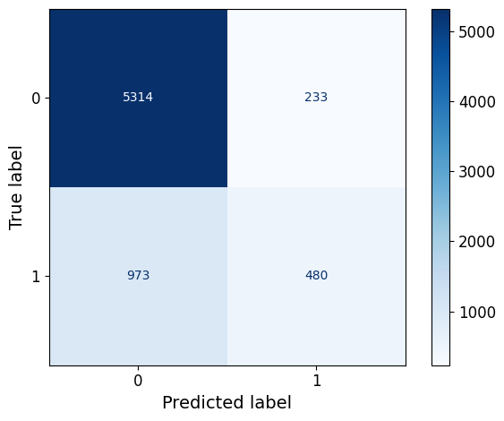

```python
from sklearn.metrics import confusion_matrix, ConfusionMatrixDisplay

# Compute confusion matrix
y_pred = clf_tree.predict(X_train)
cm = confusion_matrix(y_train, y_pred)

# Plot confusion matrix
disp = ConfusionMatrixDisplay(confusion_matrix=cm, display_labels=clf_tree.classes_)
disp.plot(values_format='d', cmap=plt.cm.Blues)
save_fig('assignment01_fig2')
```

```python
import numpy as np
# Predict the response for training dataset
np.sum(np.equal(y_train, y_pred_train)) / len(y_train)
```

```
0.8277142857142857
```

```
Saving figure assignment01_fig3
```

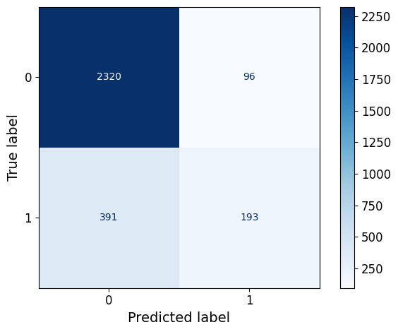

```python
# TODO Write comment
# Create confusion matrix to show the performance of the algorithm
y_pred_test = clf_tree.predict(X_test)

# Import the necessary functions
from sklearn.metrics import confusion_matrix, ConfusionMatrixDisplay

# Compute confusion matrix
cm = confusion_matrix(y_test, y_pred_test)

# Display confusion matrix
disp = ConfusionMatrixDisplay(confusion_matrix=cm)
disp.plot(cmap=plt.cm.Blues, values_format='d')
save_fig('assignment01_fig3')
```

## kNN Classification

```python
#Spliting dataset in two parts: feature set and target label
finTechDF = finTechDF.replace((np.inf, -np.inf, np.nan), 0).reset_index(drop=True)
X = finTechDF.drop('Churn', axis=1)
y = finTechDF['Churn']

#scale the data
from sklearn.preprocessing import StandardScaler
scaler = StandardScaler()
scaler.fit(X_train)
X_scaled = scaler.transform(X)
pd.DataFrame(X_scaled)
```

|  | 0 | 1 | 2 | 3 | 4 | 5 | 6 | 7 | 8 | 9 | 10 |
| --- | --- | --- | --- | --- | --- | --- | --- | --- | --- | --- | --- |
| 0 | -0.344595 | 0.295101 | -1.035726 | -1.222055 | -0.903352 | 0.645981 | 0.970714 | 0.009073 | -0.575591 | -0.577790 | -1.098232 |
| 1 | -0.458910 | 0.199916 | -1.382503 | 0.118528 | -0.903352 | -1.548034 | 0.970714 | 0.203221 | -0.575591 | 1.730732 | -1.098232 |
| 2 | -1.560488 | 0.295101 | 1.044940 | 1.331864 | 2.542677 | 0.645981 | -1.030169 | 0.227312 | -0.575591 | -0.577790 | -1.098232 |
| 3 | 0.486785 | 0.009546 | -1.382503 | -1.222055 | 0.819663 | -1.548034 | -1.030169 | -0.121395 | -0.575591 | -0.577790 | -1.098232 |
| 4 | 2.056014 | 0.390286 | -1.035726 | 0.785604 | -0.903352 | 0.645981 | 0.970714 | -0.377094 | -0.575591 | 1.730732 | -1.098232 |
| ... | ... | ... | ... | ... | ... | ... | ... | ... | ... | ... | ... |
| 9995 | 1.235026 | 0.009546 | 0.004607 | -1.222055 | 0.819663 | 0.645981 | -1.030169 | -0.079005 | -0.575591 | -0.577790 | 0.910554 |
| 9996 | -1.414996 | -0.371195 | 1.738495 | -0.304376 | -0.903352 | 0.645981 | 0.970714 | 0.015159 | -0.575591 | -0.577790 | 0.910554 |
| 9997 | 0.590707 | -0.276010 | 0.698162 | -1.222055 | -0.903352 | -1.548034 | 0.970714 | -1.018809 | -0.575591 | -0.577790 | -1.098232 |
| 9998 | 1.245419 | 0.295101 | -0.688948 | -0.021157 | 0.819663 | 0.645981 | -1.030169 | -0.137666 | 1.737346 | -0.577790 | 0.910554 |
| 9999 | 1.453263 | -1.037490 | -0.342170 | 0.859697 | -0.903352 | 0.645981 | -1.030169 | -1.086362 | -0.575591 | -0.577790 | -1.098232 |

10000 rows × 11 columns

```python
from sklearn.model_selection import train_test_split
X_train, X_test, y_train, y_test = train_test_split(X_scaled, y, test_size=0.3, random_state=42)
X_train_scaled = scaler.transform(X_train)
X_test_scaled = scaler.transform(X_test) #Test data is also scaled, but the Scaler is only fitted with the training data
```

```python
# Import KNN model
from sklearn.neighbors import KNeighborsClassifier

# Create a KNN classifier object
clf_kNN = KNeighborsClassifier(n_neighbors=3)

# Train the model using the training dataset
clf_kNN.fit(X_train_scaled,y_train)
```

```
KNeighborsClassifier(n_neighbors=3)
```

```python
# Predict the y variable for train dataset
y_pred_train_knn = clf_kNN.predict(X_train_scaled)

# Import metrics module for performance evaluation
from sklearn.metrics import accuracy_score
from sklearn.metrics import precision_score
from sklearn.metrics import recall_score
from sklearn.metrics import f1_score

# Calculate model accuracy
print("Accuracy:",accuracy_score(y_train, y_pred_train_knn))
# Calculate model precision
print("Precision:",precision_score(y_train, y_pred_train_knn))
# Calculate model recall
print("Recall:",recall_score(y_train, y_pred_train_knn))
# Calculate model f1 score
print("F1-Score:",f1_score(y_train, y_pred_train_knn))
```

```
Accuracy: 0.8908571428571429
Precision: 0.805678793256433
Recall: 0.6249139710942877
F1-Score: 0.703875968992248
```

```python
# Predict the y variable for test dataset
y_pred_test_knn = clf_kNN.predict(X_test_scaled)

# Import metrics module for performance evaluation
from sklearn.metrics import accuracy_score
from sklearn.metrics import precision_score
from sklearn.metrics import recall_score
from sklearn.metrics import f1_score


# Calculate model accuracy
print("Accuracy:",accuracy_score(y_test, y_pred_test_knn))
# Calculate model precision
print("Precision:",precision_score(y_test, y_pred_test_knn))
# Calculate model recall
print("Recall:",recall_score(y_test, y_pred_test_knn))
# Calculate model f1 score
print("F1-Score:",f1_score(y_test, y_pred_test_knn))
```

```
Accuracy: 0.8293333333333334
Precision: 0.581081081081081
Recall: 0.4417808219178082
F1-Score: 0.5019455252918288
```

```python
accuracy = []

# Calculating error for K values between 1 and 40
for i in range(1, 40):
    knn = KNeighborsClassifier(n_neighbors=i)
    knn.fit(X_train_scaled, y_train)
    pred_i = knn.predict(X_test_scaled)
    accuracy.append(accuracy_score(y_test, pred_i))
```

```
Saving figure assignment01_fig4
```

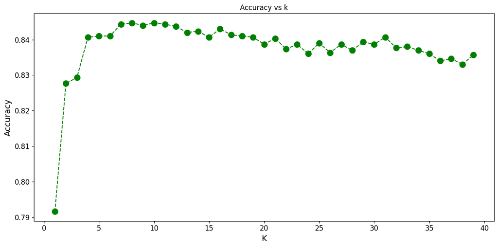

```python
import matplotlib.pyplot as plt

plt.figure(figsize=(12, 6))
plt.plot(range(1, 40), accuracy, color='green', linestyle='dashed', marker='o',
         markerfacecolor='green', markersize=10)
plt.title('Accuracy vs k')
plt.xlabel('K')
plt.ylabel('Accuracy')
save_fig('assignment01_fig4')
```

```python
# As we can see, k = 10 has the highest accuracy.
clf_kNN = KNeighborsClassifier(n_neighbors=10)

clf_kNN.fit(X_train_scaled, y_train)

y_pred_train_knn = clf_kNN.predict(X_train_scaled)

# Predict the y variable for test dataset
y_pred_test_knn = clf_kNN.predict(X_test_scaled)
```

```python
accuracyKNN = accuracy_score(y_train, y_pred_train_knn)
precisionKNN = precision_score(y_train, y_pred_train_knn)
recallKNN = recall_score(y_train, y_pred_train_knn)
f1ScoreKNN = f1_score(y_train, y_pred_train_knn)

# Calculate model accuracy
print("Accuracy:",accuracyKNN)
# Calculate model precision
print("Precision:",precisionKNN)
# Calculate model recall
print("Recall:",recallKNN)
# Calculate model f1 score
print("F1-Score:",f1ScoreKNN)
```

```
Accuracy: 0.8508571428571429
Precision: 0.8065967016491754
Recall: 0.37026841018582246
F1-Score: 0.5075471698113208
```

## Navive Bayes

```python
# Import Gaussian Naive Bayes model
from sklearn.naive_bayes import GaussianNB
# Create a Gaussian Classifier
clf_gnb = GaussianNB()
# Train the model using the training dataset
clf_gnb.fit(X_train,y_train)
```

```
GaussianNB()
```

```python
# Predict the y variable for train dataset
y_pred_train = clf_gnb.predict(X_train)
# Calculate model accuracy
print("Accuracy:",accuracy_score(y_train, y_pred_train))
# Calculate model precision
print("Precision:",precision_score(y_train, y_pred_train))
# Calculate model recall
print("Recall:",recall_score(y_train, y_pred_train))
# Calculate model f1 score
print("F1-Score:",f1_score(y_train, y_pred_train))
```

```
Accuracy: 0.8214285714285714
Precision: 0.6233292831105711
Recall: 0.35306262904335856
F1-Score: 0.45079086115992967
```

```python
# Predict the y variable for test dataset
y_pred_train = clf_gnb.predict(X_test)

accuracyGNB = accuracy_score(y_test, y_pred_test)
precisionGNB = precision_score(y_test, y_pred_test)
recallGNB = recall_score(y_test, y_pred_test)
f1ScoreGNB = f1_score(y_test, y_pred_test)

# Calculate model accuracy
print("Accuracy:", accuracyGNB)
# Calculate model precision
print("Precision:", precisionGNB)
# Calculate model recall
print("Recall:", recallGNB)
# Calculate model f1 score
print("F1-Score:", f1ScoreGNB)
```

```
Accuracy: 0.8376666666666667
Precision: 0.6678200692041523
Recall: 0.3304794520547945
F1-Score: 0.4421534936998855
```

To check, which algorithm is the most suitable, we compare the accuracies of the different algorithms

```
Saving figure assignment01_fig5
```

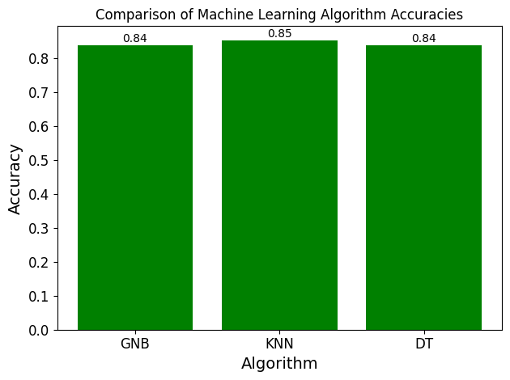

```python
# Create list of algorithms and accuracies
algorithms = ['GNB', 'KNN', 'DT']
accuracies = [accuracyGNB, accuracyKNN, accuracyDT]

# Create bar chart
plt.bar(algorithms, accuracies, color='green')

# Display accuracies as text on the bars
for i, v in enumerate(accuracies):
    plt.text(i, v+0.01, str(round(v, 2)), ha='center')

# Add chart title and axis labels
plt.title('Comparison of Machine Learning Algorithm Accuracies')
plt.xlabel('Algorithm')
plt.ylabel('Accuracy')
save_fig('assignment01_fig5')
# Show the chart
plt.show()
```

Based on the results of the calculations the kNN-algorithm performs the best.

```python
finTechDF
```

|  | CCreditScore | CAge | CTenure | CBalance | CNumOfProducts | CHasCrCard | CIsActiveMember | CEstimatedSalary | Churn | CGeography_Germany | CGeography_Spain | CGender_Male |
| --- | --- | --- | --- | --- | --- | --- | --- | --- | --- | --- | --- | --- |
| 0 | 619 | 42 | 2 | 0.00 | 1 | 1 | 1 | 101348.88 | 1 | 0 | 0 | 0 |
| 1 | 608 | 41 | 1 | 83807.86 | 1 | 0 | 1 | 112542.58 | 0 | 0 | 1 | 0 |
| 2 | 502 | 42 | 8 | 159660.80 | 3 | 1 | 0 | 113931.57 | 1 | 0 | 0 | 0 |
| 3 | 699 | 39 | 1 | 0.00 | 2 | 0 | 0 | 93826.63 | 0 | 0 | 0 | 0 |
| 4 | 850 | 43 | 2 | 125510.82 | 1 | 1 | 1 | 79084.10 | 0 | 0 | 1 | 0 |
| ... | ... | ... | ... | ... | ... | ... | ... | ... | ... | ... | ... | ... |
| 9995 | 771 | 39 | 5 | 0.00 | 2 | 1 | 0 | 96270.64 | 0 | 0 | 0 | 1 |
| 9996 | 516 | 35 | 10 | 57369.61 | 1 | 1 | 1 | 101699.77 | 0 | 0 | 0 | 1 |
| 9997 | 709 | 36 | 7 | 0.00 | 1 | 0 | 1 | 42085.58 | 1 | 0 | 0 | 0 |
| 9998 | 772 | 42 | 3 | 75075.31 | 2 | 1 | 0 | 92888.52 | 1 | 1 | 0 | 1 |
| 9999 | 792 | 28 | 4 | 130142.79 | 1 | 1 | 0 | 38190.78 | 0 | 0 | 0 | 0 |

10000 rows × 12 columns

## 2. Select the machine learning model that you have chosen in task 1. Now try optimizing your results by applying the advanced concepts (lecture 04). Use cross-validation (lecture 04) when evaluating your results. Describe your approach, interpret the performance, and justify which machine learning model you would choose.

```python
feature_set = ['CCreditScore', 'CTenure', 'CBalance', 'CNumOfProducts', 'CHasCrCard', 'CIsActiveMember', 'CEstimatedSalary', 'CGeography_Germany', 'CGeography_Spain', 'CGender_Male', 'CAge']
X = finTechDF[feature_set]
y = finTechDF.Churn
finTechDF.Churn.value_counts()
```

```
0    7963
1    2037
Name: Churn, dtype: int64
```

```python
from imblearn.over_sampling import RandomOverSampler
from imblearn.under_sampling import RandomUnderSampler
from imblearn.over_sampling import SMOTE

ros = RandomOverSampler(random_state=0)

X_oversampled, y_oversampled = ros.fit_resample(X, y)
```

```python
y_oversampled.value_counts()
```

```
1    7963
0    7963
Name: Churn, dtype: int64
```

```python
# Partition data into training and testing set
from sklearn.model_selection import train_test_split
X_train_OS, X_test_OS, y_train_OS, y_test_OS = train_test_split(X_oversampled, y_oversampled, test_size=0.3, random_state=42)
```

```
Saving figure assignment01_fig6
```

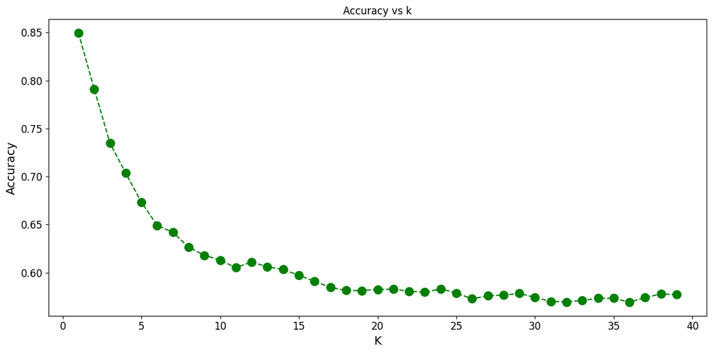

```python
accuracy = []

# Calculating error for K values between 1 and 40
for i in range(1, 40):
    knn = KNeighborsClassifier(n_neighbors=i)
    knn.fit(X_train_OS, y_train_OS)
    pred_i = knn.predict(X_test_OS)
    accuracy.append(accuracy_score(y_test_OS, pred_i))

plt.figure(figsize=(12, 6))
plt.plot(range(1, 40), accuracy, color='green', linestyle='dashed', marker='o',
         markerfacecolor='green', markersize=10)
plt.title('Accuracy vs k')
plt.xlabel('K')
plt.ylabel('Accuracy')
save_fig('assignment01_fig6')
```

```python
# As we can see, k = 1 has the highest accuracy.
clf_kNN_OS = KNeighborsClassifier(n_neighbors=1)

# Train the model using training dataset
clf_kNN_OS = clf_kNN_OS.fit(X_train_OS,y_train_OS)
```

```
Saving figure assignment01_fig7
```

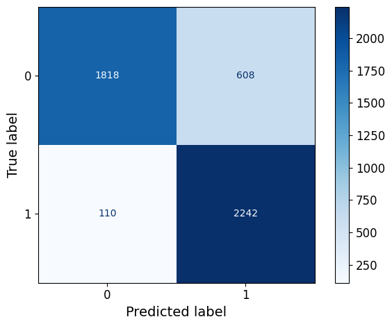

```python
# Predict the response for test dataset
y_pred_test_OS = clf_kNN_OS.predict(X_test_OS)

# Import the necessary functions
from sklearn.metrics import confusion_matrix, ConfusionMatrixDisplay

# Compute confusion matrix
cm = confusion_matrix(y_test_OS, y_pred_test_OS)

# Display confusion matrix
disp = ConfusionMatrixDisplay(confusion_matrix=cm)
disp.plot(cmap=plt.cm.Blues, values_format='d')
save_fig('assignment01_fig7')
```

```python
# Oversampling
# Import metrics module for performance evaluation
from sklearn.metrics import accuracy_score
# Calculate model accuracy
print("Accuracy:",accuracy_score(y_test_OS, y_pred_test_OS))
```

```
Accuracy: 0.8497279196316451
```

```python
from sklearn.model_selection import cross_val_score

scores = cross_val_score(clf_kNN_OS, X_train_OS, y_train_OS, scoring='accuracy')
print("Cross validation scores: {}". format(scores))
print("Average cross-validation score: {:.2f}".format(scores.mean()))
print("Standard deviation: {:.2f}".format(scores.std()))
```

```
Cross validation scores: [0.80986547 0.81165919 0.81928251 0.80888291 0.82727681]
Average cross-validation score: 0.82
Standard deviation: 0.01
```

```python
# accuracy scores
y_pred_train_OS = clf_kNN_OS.predict(X_train_OS)
print("Accuracy of training data:", accuracy_score(y_train_OS, y_pred_train_OS))
print("Accuracy of test data:", accuracy_score(y_test_OS, y_pred_test_OS))
print("Accuracy of cross-validation:", cross_val_score(clf_kNN_OS, X_train_OS,y_train_OS, scoring='accuracy').mean())
```

```
Accuracy of training data: 1.0
Accuracy of test data: 0.8497279196316451
Accuracy of cross-validation: 0.8153933775527242
```

The accuracy of the cross validation is worse than the performance of the training set, thus the model seems to suffer from high variance (i.e. overfitting).

# 3. Apply one ensemble learning technique (lecture 05) to see whether those techniques lead to a better performance than in task 1 and task 2. You should also apply the advanced concepts (lecture 04) to improve the model. Describe your approach, interpret the performance, and justify the final machine learning selection.

```python
# Split the data into training and testing sets
X_train_OS, X_test_OS, y_train_OS, y_test_OS = train_test_split(X_oversampled, y_oversampled, test_size=0.3, random_state=42)
# Create a Random Forest classifier and train it using the training data
from sklearn.ensemble import RandomForestClassifier

clf_RF_OS = RandomForestClassifier(random_state=42)
clf_RF_OS.fit(X_train_OS, y_train_OS)
```

```
RandomForestClassifier(random_state=42)
```

```python
# Use the trained classifier to make predictions on the testing data
y_pred_test_OS = clf_RF_OS.predict(X_test_OS)
# Evaluate the performance of the Random Forest classifier
from sklearn.metrics import classification_report

print(classification_report(y_test_OS, y_pred_test_OS))
```

```
              precision    recall  f1-score   support

           0       0.97      0.91      0.94      2426
           1       0.91      0.97      0.94      2352

    accuracy                           0.94      4778
   macro avg       0.94      0.94      0.94      4778
weighted avg       0.94      0.94      0.94      4778
```

```python
from sklearn.model_selection import cross_val_score
from sklearn.ensemble import RandomForestClassifier

# Define the model to use for cross-validation
model = RandomForestClassifier(random_state=42)

# Perform cross-validation
cv_scores = cross_val_score(model, X_oversampled, y_oversampled, cv=5)

# Print the cross-validation scores
print(cv_scores)
```

```
[0.95260515 0.95572998 0.95604396 0.96075353 0.95918367]
```

```python
clf_RF_OS.get_params()
```

```
{'bootstrap': True,
 'ccp_alpha': 0.0,
 'class_weight': None,
 'criterion': 'gini',
 'max_depth': None,
 'max_features': 'sqrt',
 'max_leaf_nodes': None,
 'max_samples': None,
 'min_impurity_decrease': 0.0,
 'min_samples_leaf': 1,
 'min_samples_split': 2,
 'min_weight_fraction_leaf': 0.0,
 'n_estimators': 100,
 'n_jobs': None,
 'oob_score': False,
 'random_state': 42,
 'verbose': 0,
 'warm_start': False}
```

```python
from sklearn.model_selection import GridSearchCV
from sklearn.ensemble import RandomForestClassifier
import numpy as np

# Define the parameter grid to search over
param_grid = {
    'n_estimators': [50, 100, 200],
    'max_depth': [None, 5, 10],
    'max_features': ['sqrt', 'log2']
}

# Create a Random Forest classifier
clf_RF_OS = RandomForestClassifier(random_state=42)

# Create a GridSearchCV object with the classifier and parameter grid
grid_search = GridSearchCV(clf_RF_OS, param_grid, cv=5)

# Fit the GridSearchCV object to the training data
grid_search.fit(X_train_OS, y_train_OS)

# Print the best parameters and best score
print("Best parameters: ", grid_search.best_params_)
print("Best score: ", grid_search.best_score_)

# Use the best estimator to make predictions on the testing data
y_pred_test = grid_search.best_estimator_.predict(X_test_OS)

# Print the classification report
from sklearn.metrics import classification_report
print(classification_report(y_test_OS, y_pred_test))
```

```
Best parameters:  {'max_depth': None, 'max_features': 'sqrt', 'n_estimators': 100}
Best score:  0.9276096381373135
              precision    recall  f1-score   support

           0       0.97      0.91      0.94      2426
           1       0.91      0.97      0.94      2352

    accuracy                           0.94      4778
   macro avg       0.94      0.94      0.94      4778
weighted avg       0.94      0.94      0.94      4778
```

The values using the Random Forest Classifier are much better than the values from task 1 and 2. The accuracy of 0.94 is the best result so far.